# IE423 Project Part 1 Report

**Prepared by:**

Gamze Gür

Zeynep Sude Karakuş

Ahmet Selim Gül

## Introduction

This report is dedicated to visualization and analysis of stock price data of companies listed on Borsa Istanbul. The primary goal of this analysis is to understand the market dynamics and assess the performance of individual companies. To achieve this, we have examined stock price data for six companies from varying sectors, focusing on the years 2015 and 2016. The companies are as follows: AEFES, AKBNK, MGROS, CCOLA, THYAO, SISE. The objective is to uncover patterns, outliers, and potential correlations within their stock price data. Firstly, for each company, boxplots are generated for each month. Additionally, 3-sigma limits for each month are calculated and if the number of outliers accounted for more than 1% of the data, an exploration into the relationship between stock prices and Google Trends data is conducted, aiming to reveal insights into potential connections between online search behavior and stock market trends during the specified years. The threshold is set as 1% to decrease the number of graphs in the report.

## The Code and Explanations

Firstly, the necessary Python libraries are imported: pandas for creating and manipulating dataframes, numpy for mathematical calculations and matplotlib.pyplot for data visualization.

```python
# Import statements
import pandas as pd
import numpy as np
import matplotlib.pyplot as plt
```

The data is read into a dataframe and the timestamp object is converted to datetime.

```python
# Read in the data
df = pd.read_csv("all_ticks_wide.csv")
```

```python
# Print the first 5 rows
df.head(5)
```

|  | timestamp | AEFES | AKBNK | AKSA | AKSEN | ALARK | ALBRK | ANACM | ARCLK | ASELS | ... | TTKOM | TUKAS | TUPRS | USAK | VAKBN | VESTL | YATAS | YKBNK | YUNSA | ZOREN |
| --- | --- | --- | --- | --- | --- | --- | --- | --- | --- | --- | --- | --- | --- | --- | --- | --- | --- | --- | --- | --- | --- |
| 0 | 2012-09-17T06:45:00Z | 22.3978 | 5.2084 | 1.7102 | 3.87 | 1.4683 | 1.1356 | 1.0634 | 6.9909 | 2.9948 | ... | 4.2639 | 0.96 | 29.8072 | 1.0382 | 3.8620 | 1.90 | 0.4172 | 2.5438 | 2.2619 | 0.7789 |
| 1 | 2012-09-17T07:00:00Z | 22.3978 | 5.1938 | 1.7066 | 3.86 | 1.4574 | 1.1275 | 1.0634 | 6.9259 | 2.9948 | ... | 4.2521 | 0.96 | 29.7393 | 1.0382 | 3.8529 | 1.90 | 0.4229 | 2.5266 | 2.2462 | 0.7789 |
| 2 | 2012-09-17T07:15:00Z | 22.3978 | 5.2084 | 1.7102 | NaN | 1.4610 | 1.1356 | 1.0679 | 6.9909 | 2.9855 | ... | 4.2521 | 0.97 | 29.6716 | 1.0463 | 3.8436 | 1.91 | 0.4229 | 2.5266 | 2.2566 | 0.7789 |
| 3 | 2012-09-17T07:30:00Z | 22.3978 | 5.1938 | 1.7102 | 3.86 | 1.4537 | 1.1275 | 1.0679 | 6.9584 | 2.9855 | ... | 4.2521 | 0.97 | 29.7393 | 1.0382 | 3.8529 | 1.91 | 0.4286 | 2.5324 | 2.2619 | 0.7860 |
| 4 | 2012-09-17T07:45:00Z | 22.5649 | 5.2084 | 1.7102 | 3.87 | 1.4574 | 1.1356 | 1.0725 | 6.9909 | 2.9760 | ... | 4.2521 | 0.97 | 29.8072 | 1.0382 | 3.8620 | 1.90 | 0.4286 | 2.5324 | 2.2619 | 0.7789 |

5 rows × 61 columns

```python
# convert the timestamp column to a datetime object
df["timestamp"] = pd.to_datetime(df["timestamp"], format="%Y-%m-%dT%H:%M:%SZ")
```

### Functions

4 functions are used to manipulate and visualize the data:

1. boxplot_generator: Accepts the stock price data, start_year, end_year, start_month, end_month, and the stock name as parameters, drops NA values, and plots boxplots for each month in the specified timeframe.
2. compare_price_and_trends: Accepts the Google Trends data, the stock price data, start_year, end_year, start_month, end_month, and the stock name as parameters, drops NA values, normalizes and plots both data in the same graph in the specified timeframe. Both data are normalized for better visualization.
3. outlier_calculator: Accepts the stock price data, start_year, end_year, start_month, end_month, and the stock name as parameters, drops NA values, and for each month, computes the mean, standard deviation, control limits based on 3-sigma limits, and plots the control chart if the outliers account for more than 1% of the data.
4. prepare_trends_data: Accepts Google Trends data as parameter and prepares it for further use.

```python
# Function to plot the boxplots of a stock between two dates
def boxplot_generator(df=df, start_year=2015, end_year=2016, start_month=1, end_month=12, stock_name="AEFES"):

    all_data = []

    for i in range(start_year, end_year + 1):
        for j in range(start_month, end_month + 1):
            filtered_data = df[(df.timestamp.dt.month==j) & (df.timestamp.dt.year==i)]
            filtered_data = filtered_data[["timestamp", stock_name]]
            filtered_data.dropna(inplace=True)
            all_data.append(filtered_data[stock_name])

    fig, ax = plt.subplots(figsize=(24, 7))
    ax.boxplot(all_data, flierprops={'marker': '.', 'markerfacecolor': 'red', 'markersize': 8})
    ax.set_xticklabels([str(i) + "-" + str(j) for i in range(start_year, end_year + 1) for j in range(start_month, end_month + 1)])
    ax.set_ylabel("Price")
    ax.set_xlabel("Year-Month")
    ax.set_title("Boxplots of " + stock_name + " between " + str(start_year) + "-" + str(start_month) + " and " + str(end_year) + "-" + str(end_month))
```

```python
# Function to plot the Google trends data and price of a stock between two dates
def compare_price_and_trends(trends_data, df=df, start_year=2015, end_year=2015, start_month=2, end_month=2, stock_name="AEFES"):

    fig, ax = plt.subplots(figsize=(12, 5))

    for i in range(start_year, end_year + 1):
        for j in range(start_month, end_month + 1):
            filtered_data = df[(df.timestamp.dt.month==j) & (df.timestamp.dt.year==i)]
            filtered_data = filtered_data[["timestamp", stock_name]]
            filtered_data.dropna(inplace=True)
            filtered_data[stock_name] = (filtered_data[stock_name]-filtered_data[stock_name].mean())/filtered_data[stock_name].std()
            trends_data["Interest"] = (trends_data["Interest"]-trends_data["Interest"].mean())/trends_data["Interest"].std()
            ax.plot(filtered_data["timestamp"], filtered_data[stock_name], label="Price")
    ax.plot(trends_data["Day"], trends_data["Interest"], color="red", label="Trend")
    ax.legend()
    title = f"{start_month:02d}-{start_year} {stock_name}"
    ax.set_title(title)
    plt.xticks(rotation=45, ha='right')
```

```python
# Function to calculate the monthly outliers of a stock and plot the monthly stock prices if outliers account for more than 1% of the data
def outlier_calculator(df=df, start_year=2015, end_year=2016, start_month=1, end_month=12, stock_name="AEFES"):
    for i in range(start_year, end_year + 1):
        for j in range(start_month, end_month + 1):
            filtered_data = df[(df.timestamp.dt.month==j) & (df.timestamp.dt.year==i)]
            filtered_data = filtered_data[["timestamp", stock_name]]
            filtered_data.dropna(inplace=True)
            mean = np.mean(filtered_data[stock_name])
            standard_deviation = np.std(filtered_data[stock_name])
            lower_limit = mean - 3 * standard_deviation
            upper_limit = mean + 3 * standard_deviation
            outliers = filtered_data[(filtered_data[stock_name] < lower_limit) | (filtered_data[stock_name] > upper_limit)]
            outlier_percentage = len(outliers) / len(filtered_data) * 100
            if len(outliers) > 0 and outlier_percentage > 1:
                print(f"{i}-{j}:\nMean of {stock_name} prices: {mean:.2f}\nStandard deviation of {stock_name} prices: {standard_deviation:.2f}\nNumber of outliers = {len(outliers)}\nPercentage of outliers = {len(outliers) / len(filtered_data) * 100:.2f}%\n")
                fig, axs = plt.subplots(figsize=(12, 6))
                axs.set_title(f"Stock prices of {stock_name} in {i}-{j}")
                axs.set_ylabel("Price")
                axs.set_xlabel("Date")
                axs.plot(filtered_data["timestamp"], upper_limit * np.ones(len(filtered_data)), color='red', label="Upper Control Limit")
                axs.plot(filtered_data["timestamp"], lower_limit * np.ones(len(filtered_data)), color='blue', label="Lower Control Limit")
                axs.plot(filtered_data["timestamp"], mean * np.ones(len(filtered_data)), color='orange', label="Mean")
                axs.plot(filtered_data["timestamp"], filtered_data[stock_name], color='black', label="Stock Price")
                axs.legend()
```

```python
# Function to prepare the Google trends data for plotting
def prepare_trends_data(data):
    data = pd.read_excel(data)
    data["Day"] = pd.to_datetime(data["Day"])
    return data
```

## ANALYSIS OF SELECTED COMPANIES

**MGROS:**

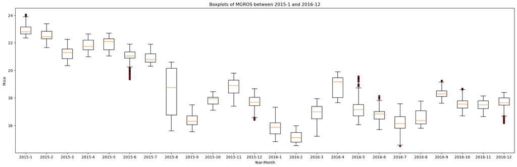

```python
boxplot_generator(stock_name="MGROS")
```

```
2015-6:
Mean of MGROS prices: 21.00
Standard deviation of MGROS prices: 0.47
Number of outliers = 14
Percentage of outliers = 2.37%

2016-12:
Mean of MGROS prices: 17.66
Standard deviation of MGROS prices: 0.46
Number of outliers = 8
Percentage of outliers = 1.18%
```

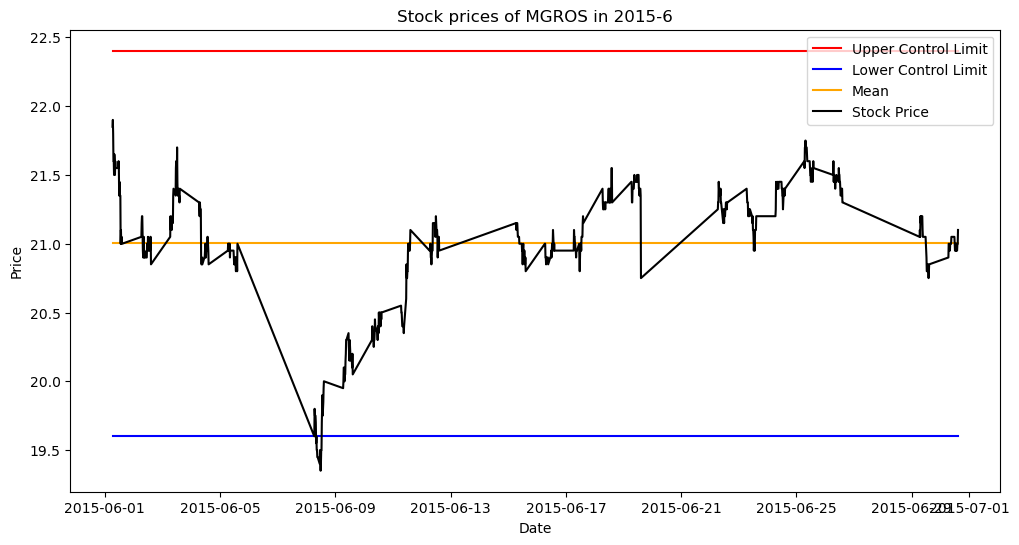

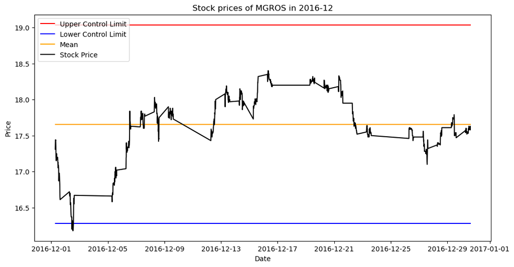

```python
outlier_calculator(stock_name="MGROS")
```

When examining the IST:MGROS trend on Google Trends alongside the stock price data from the 12th month of 2016 in an attempt to understand the outliers, the extracted graph indicates an absence of an obvious correlation. However, it can be noted that during the day of outliers, there seems to be an increased Google trend for IST:MGROS :

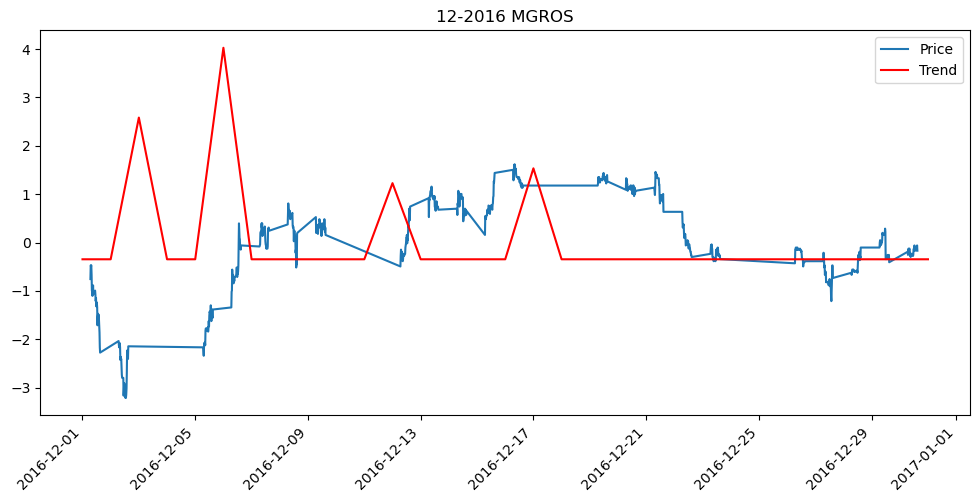

```python
compare_price_and_trends(trends_data=prepare_trends_data("12-2016-MGROS.xlsx"), start_year=2016, end_year=2016, start_month=12, end_month=12, stock_name="MGROS")
```

In analyzing the connection between IST:MGROS Google Trend data and MGROS stock price data in June 2015, a clear correlation is not evident. While no apparent correlation is observed overall, there is an increase in search volume during the days with outliers, suggesting a potential connection. However, this increase does not seem very significant regarding the remaining data:

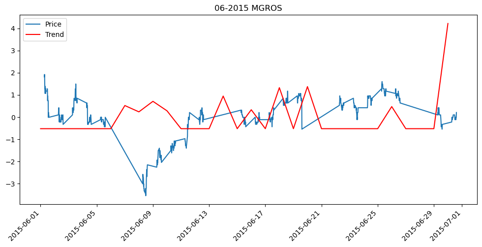

```python
compare_price_and_trends(trends_data=prepare_trends_data("6-2015-mgros.xlsx"), start_year=2015, end_year=2015, start_month=6, end_month=6, stock_name="MGROS")
```

**CCOLA:**

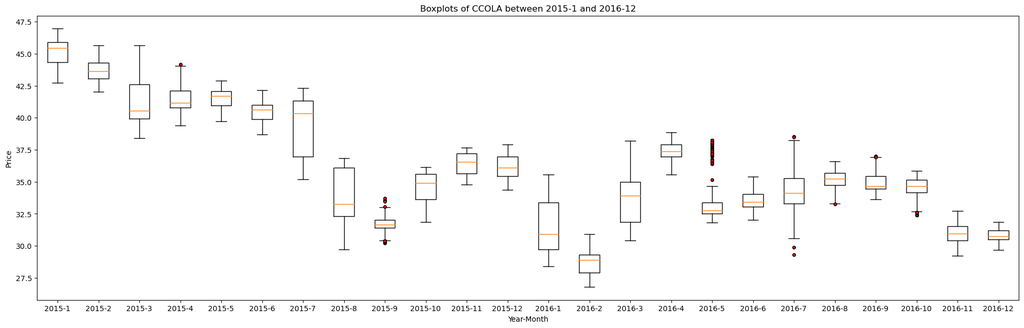

```python
boxplot_generator(stock_name="CCOLA")
```

```
2016-5:
Mean of CCOLA prices: 33.31
Standard deviation of CCOLA prices: 1.50
Number of outliers = 30
Percentage of outliers = 4.76%
```

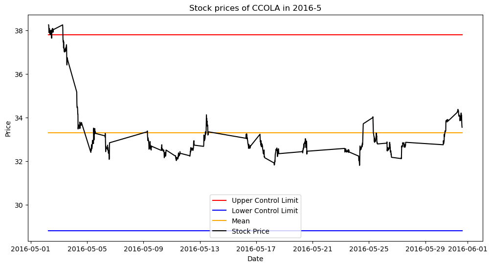

```python
outlier_calculator(stock_name="CCOLA")
```

Similarly, for the CCOLA stock prices in May 2016, no correlation is evident with the IST:CCOLA search volumes data from the same month:

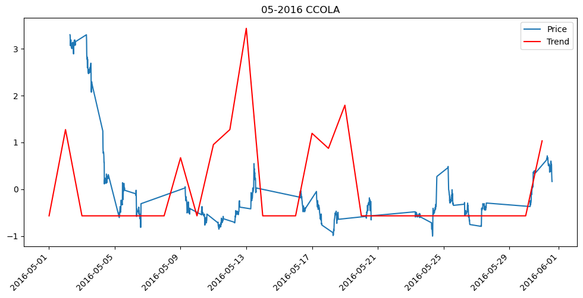

```python
compare_price_and_trends(trends_data=prepare_trends_data("5-2016-CCOLA.xlsx"), start_year=2016, end_year=2016, start_month=5, end_month=5, stock_name="CCOLA")
```

**AEFES:**

The boxplots of AEFES between January 2015 and December 2016 are shown below. There are outliers in February 2015, August 2015, October 2015, December 2015, January, 2016, April 2016, May 2016, July 2016, October 2016, and December 2016.

February 2015, August 2015, and May 2016 have numerous outliers. The reason for the outliers in February 2015 may be connected to international events. According to the news reports at that date, decreasing oil prices have affected companies that have businesses in Russia negatively. AEFES was one of them, so its stock prices decreased. That fast decrease created some outliers. In August 2015, the whole stock market was down and there was significant volatility. This was probably the result of terror attacks in the country. In May 2016, the stock market saw heavy losses again. It was probably the result of the resignation of the prime minister.

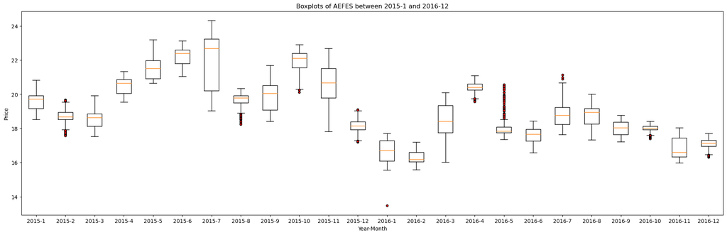

```python
boxplot_generator(stock_name="AEFES")
```

Employing the 3-sigma rule for AEFES reveals that one month exceeds the 1% outlier threshold: May 2016. It exhibits 30 outliers, concentrated in the initial days of the month:

```
2016-5:
Mean of AEFES prices: 18.14
Standard deviation of AEFES prices: 0.70
Number of outliers = 30
Percentage of outliers = 4.80%
```

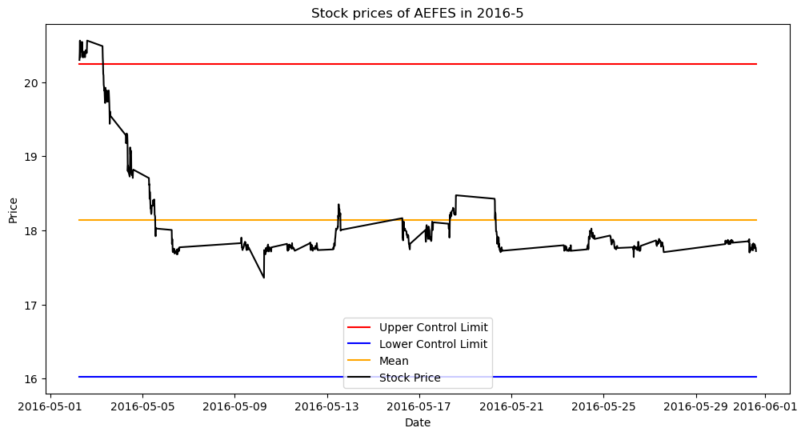

```python
outlier_calculator(stock_name="AEFES")
```

As seen in the graph above, the reason for the outliers is the significant decrease in the price at the start of the month. As stated above, this decrease is not particular to AEFES. It is the result of the resignation of the prime minister on May 5th. The normalized Google Trends data for IST:AEFES and the normalized stock price data for AEFES are shown in a graph below:

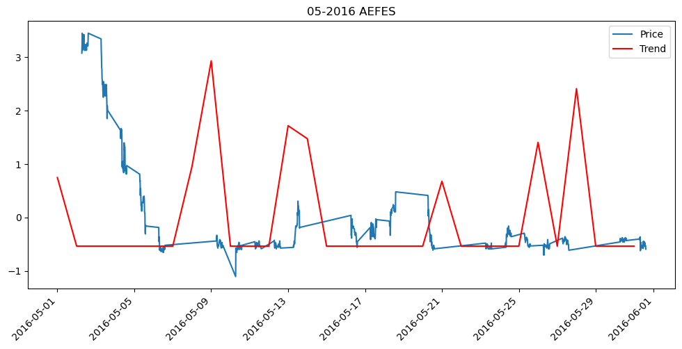

```python
compare_price_and_trends(trends_data=prepare_trends_data("5-2016-aefes.xlsx"), start_year=2016, end_year=2016, start_month=5, end_month=5, stock_name="AEFES")
```

After the significant price decrease at the beginning of the month, the search volume increases. However, there doesn’t seem to be a correlation between the search volume and the outliers as there were several other search volume increases during the month when the prices were stable. This is expected as all the stock market was suffering losses and there was no particular reason for people to search AEFES.

**THYAO:**

The boxplots of THYAO between January 2015 and December 2016 are shown above. A general decline starting in late 2015 and continuing into 2016 is observed in the first glance at the box plots. Based on a general industry research and company statements, it has been found that Turkish Airlines (THYAO) performed poorly in 2016 due to adverse developments believed to have a direct impact on air transportation, such as geopolitical risks and global security concerns in the regions where THYAO operates.

Monthly examination reveals several outliers in June 2015, October 2015, November 2015, December 2015, August 2016, September 2016, and November 2016. When a more detailed examination is conducted for the months in which outliers occurred, there is only one month, September 2016, in THYAO data that, according to 3-sigma limits, outliers account for more than 1% of the data.

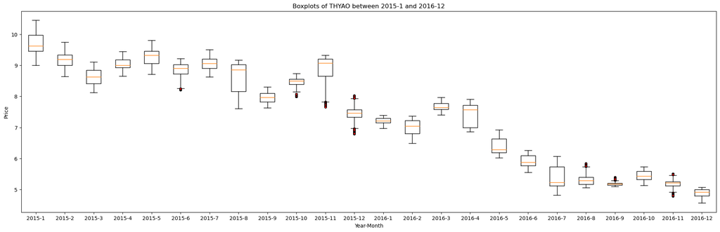

```python
boxplot_generator(stock_name="THYAO")
```

```
2016-9:
Mean of THYAO prices: 5.20
Standard deviation of THYAO prices: 0.06
Number of outliers = 8
Percentage of outliers = 1.48%
```

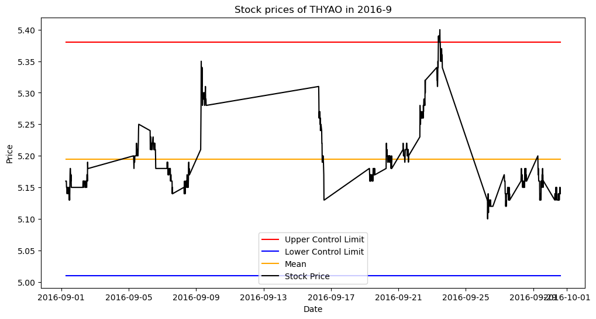

```python
outlier_calculator(stock_name="THYAO")
```

These outliers were observed on September 23, 2016.

Google Trends data for IST:THYAO and the stock price data of THYAO are plotted below to understand the connection between them:

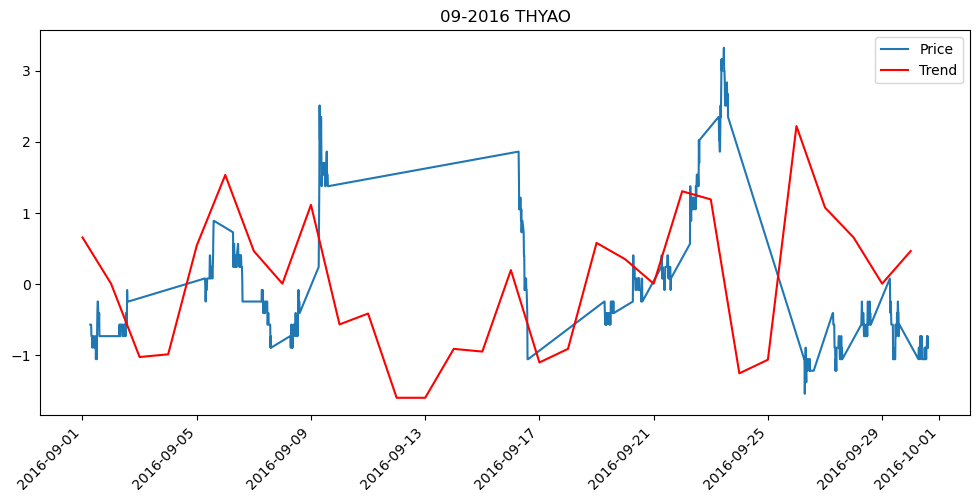

```python
compare_price_and_trends(trends_data=prepare_trends_data("9-2016-thyao.xlsx"), start_year=2016, end_year=2016, start_month=9, end_month=9, stock_name="THYAO")
```

**AKBNK:**

The boxplots of AKBNK between January 2015 and December 2016 are shown above. There are outliers in February 2015, June 2015, October 2015, December 2015, May 2016, and November 2016. February 2015, June 2015, October 2015, and November 2016 have numerous outliers. The outliers in February 2015 are the result of the significant decrease in the price. The outliers in June 2015 seem to be different as the mean for June is not very different from the mean for May. The outliers may be the result of price volatility and the volatility may be the result of the general elections on June 7th that didn’t give any party the power to form a government. The outliers in October 2015 are the result of the significant increase in the price, and the outliers in November 2016 are the result of the significant decrease in the price, once again.

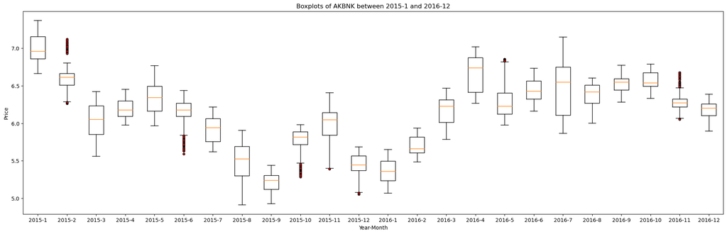

```python
boxplot_generator(stock_name="AKBNK")
```

Employing the 3-sigma rule for AKBNK reveals that one month exceeds the 1% outlier threshold: June 2015. June 2015 exhibits 12 outliers, concentrated on June 8th:

```
2015-6:
Mean of AKBNK prices: 6.17
Standard deviation of AKBNK prices: 0.16
Number of outliers = 12
Percentage of outliers = 2.01%
```

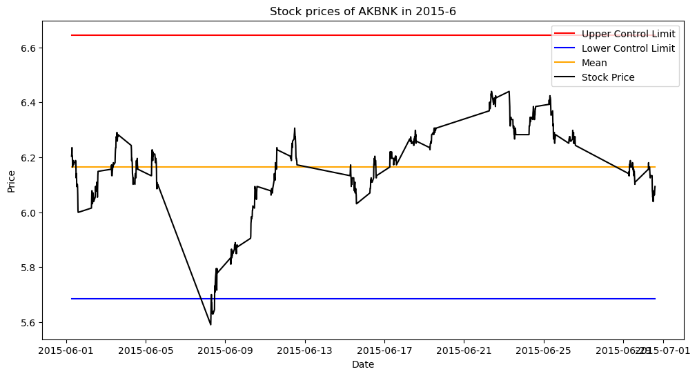

```python
outlier_calculator(stock_name="AKBNK")
```

As seen in the graph above, all of the outliers are on June 8th, one day after the elections on June 7th. It’s probable that, initially, the uncertainty about the political future of the country motivated people to sell their shares but eventually, the stock price came back to what it was a few days ago.

The normalized Google Trends data for AKBNK and the normalized stock price data for AKBNK are shown in a graph below:

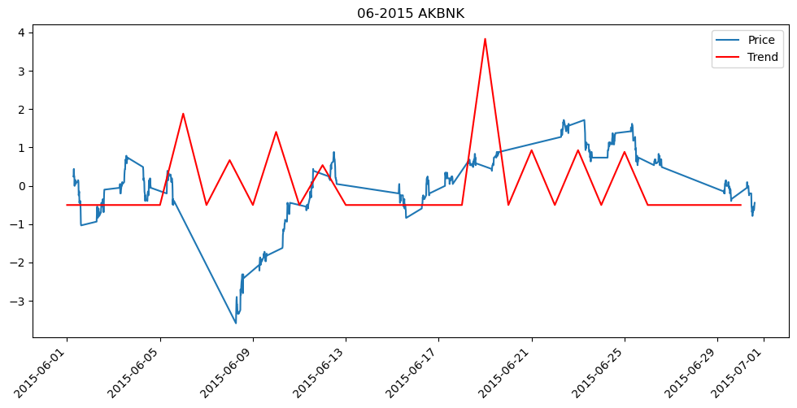

```python
compare_price_and_trends(trends_data=prepare_trends_data("6-2015-akbnk.xlsx"), start_year=2015, end_year=2015, start_month=6, end_month=6, stock_name="AKBNK")
```

As seen in the graph above, when the price saw losses, the search volumes increased. However, between June 18th and June 26th, where the price changes were minimal compared to the loss one June 8th, the search volume was higher than the search volumes at the beginning of the month, so there may be other reasons for the increases. One possible reason is that the search volume was small, so small increases made a huge impact.

**SISE:**

The boxplots of SISE between January 2015 and December 2016 are shown above. It is observed that the data, which could be considered stable in 2015, showed a significant increase at the beginning of 2016 and then stabilized again. According to market research and company statements, the increase in the first half of 2016 can be attributed to the renewed brand architecture, which garnered significant attention due to its innovative and special solutions presented at the Istanbul Glass 2016 Fair.

Monthly examination reveals several outliers in January 2015, Macrh 2015, January 2016, February 2016, March 2016, April 2016, May 2016 and December 2016.

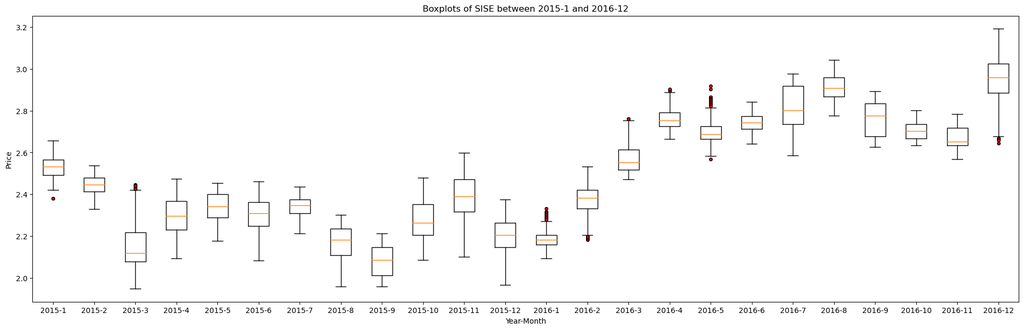

```python
boxplot_generator(stock_name="SISE")
```

When a more detailed examination is conducted for the months in which outliers occurred, there is only one month, May 2016, in SISE data that, according to 3-sigma limits, outliers account for more than 1% of the data.

```
2016-5:
Mean of SISE prices: 2.70
Standard deviation of SISE prices: 0.05
Number of outliers = 9
Percentage of outliers = 1.43%
```

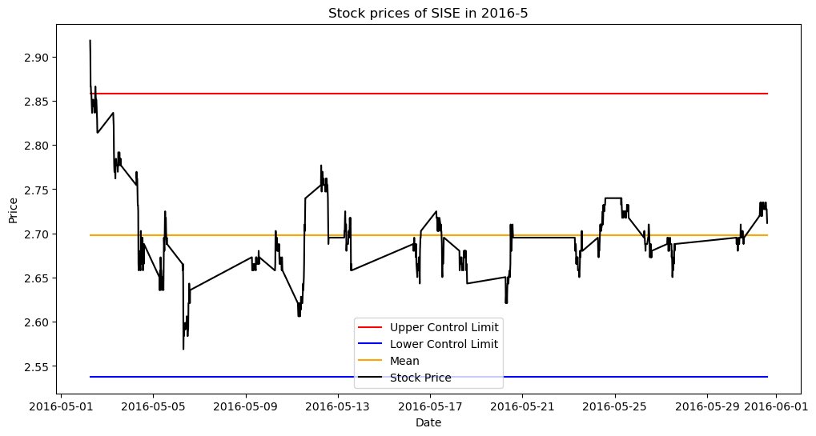

```python
outlier_calculator(stock_name="SISE")
```

These outliers were observed on May 2, 2016. Google Trends data for IST:SISE and the stock price data of SISE are plotted below to understand the connection between them.

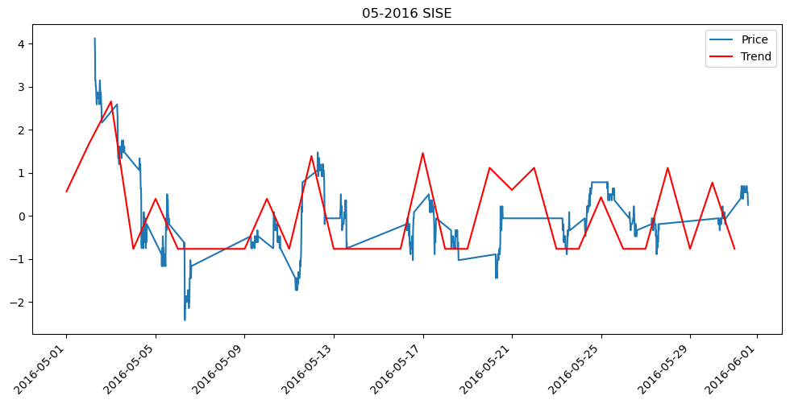

```python
compare_price_and_trends(trends_data=prepare_trends_data("05-2016-sise.xlsx"), start_year=2016, end_year=2016, start_month=5, end_month=5, stock_name="SISE")
```

Although not perfectly aligning on specific days of the month, there are similar trends and directions in both search patterns and prices. Especially in the drop after May 2nd, and the rises after May 11th and May 16th. Additionally, when examining the search topics in May, stock-related subjects were also present. However, when analyzing the outlier day, May 2nd, no relationship could be found. When examining the most searched topics on Google Trends for May 2nd, no data related to the company was found. One possible reason for this could be that the outlier value did not cause a significant deviation from the mean, so it didn't result in a noticeable spike in Google searches. Additionally, considering May 1st is both a weekend and a special holiday in our country and the recent record-low level of the dollar, it is thought that the week started with a high but stabilized afterward due to these factors.

## Conclusion

In conclusion, the analysis of stock price data for selected companies listed on Borsa Istanbul reveals intriguing patterns and outliers in specific months. Anomalies, possibly influenced by external factors, are detected for all companies employing boxplot and 3-sigma approaches, and potential reasons are investigated. While certain correlations with Google Trends are explored, the presence of external factors and the complexity of market behaviors makes it challenging to establish definitive links between stock prices and Google Trends data.